# NYPD Shooting Incident

Jia Liu

2023-04-23

## Importing data

Let’s import the data first:

```r
nypd <- read.csv("https://data.cityofnewyork.us/api/views/833y-fsy8/rows.csv?accessType=DOWNLOAD")
```

## Data wrangling

There are 19 columns, of which I’ll only need the occurrence date, boroughs, shooting outcome and the demographics of the perpetrator and victim for my analysis.

```r
nypd <- nypd %>%
select(OCCUR_DATE, BORO, STATISTICAL_MURDER_FLAG, PERP_RACE, PERP_SEX, PERP_AGE_GROUP, VIC_RACE, VIC_SEX, VIC_AGE_GROUP) %>%
mutate(DATE = mdy(OCCUR_DATE))
head(nypd)
```

```
##   OCCUR_DATE     BORO STATISTICAL_MURDER_FLAG PERP_RACE PERP_SEX PERP_AGE_GROUP
## 1 05/27/2021   QUEENS                   false
## 2 06/27/2014    BRONX                   false
## 3 11/21/2015   QUEENS                    true
## 4 10/09/2015    BRONX                   false
## 5 02/19/2009    BRONX                    true     BLACK        M          25-44
## 6 10/21/2020 BROOKLYN                    true
##         VIC_RACE VIC_SEX VIC_AGE_GROUP       DATE
## 1          BLACK       M         18-24 2021-05-27
## 2          BLACK       M         18-24 2014-06-27
## 3          WHITE       M         25-44 2015-11-21
## 4 WHITE HISPANIC       M           <18 2015-10-09
## 5          BLACK       M         45-64 2009-02-19
## 6          BLACK       M         25-44 2020-10-21
```

There’s a large amount of missing values in PERP_RACE, PERP_SEX, and PERP_AGE_GROUP because the perpetrators may not always be identified. I’ll replace them all with “UNKNOWN”.Then, I’ll convert the columns to the appropriate data types.

```r
nypd[nypd == ''] <- NA
nypd <- nypd %>%
  replace_na(list(PERP_RACE = "UNKNOWN", PERP_SEX = "U", PERP_AGE_GROUP = "UNKNOWN"))
nypd$BORO = as.factor(nypd$BORO)
nypd$STATISTICAL_MURDER_FLAG = as.factor(nypd$STATISTICAL_MURDER_FLAG)
nypd$PERP_RACE = as.factor(nypd$PERP_RACE)
nypd$PERP_SEX = as.factor(nypd$PERP_SEX)
nypd$PERP_AGE_GROUP = as.factor(nypd$PERP_AGE_GROUP)
nypd$VIC_RACE = as.factor(nypd$VIC_RACE)
nypd$VIC_SEX = as.factor(nypd$VIC_SEX)
nypd$VIC_AGE_GROUP = as.factor(nypd$VIC_AGE_GROUP)
summary(nypd)
```

```
##   OCCUR_DATE                   BORO       STATISTICAL_MURDER_FLAG
##  Length:27312       BRONX        : 7937   false:22046
##  Class :character   BROOKLYN     :10933   true : 5266
##  Mode  :character   MANHATTAN    : 3572
##                     QUEENS       : 4094
##                     STATEN ISLAND:  776
##
##
##           PERP_RACE       PERP_SEX     PERP_AGE_GROUP
##  BLACK         :11432   (null):  640   UNKNOWN:12492
##  UNKNOWN       :11146   F     :  424   18-24  : 6222
##  WHITE HISPANIC: 2341   M     :15439   25-44  : 5687
##  BLACK HISPANIC: 1314   U     :10809   <18    : 1591
##  (null)        :  640                  (null) :  640
##  WHITE         :  283                  45-64  :  617
##  (Other)       :  156                  (Other):   63
##                            VIC_RACE     VIC_SEX   VIC_AGE_GROUP
##  AMERICAN INDIAN/ALASKAN NATIVE:   10   F: 2615   <18    : 2839
##  ASIAN / PACIFIC ISLANDER      :  404   M:24686   1022   :    1
##  BLACK                         :19439   U:   11   18-24  :10086
##  BLACK HISPANIC                : 2646             25-44  :12281
##  UNKNOWN                       :   66             45-64  : 1863
##  WHITE                         :  698             65+    :  181
##  WHITE HISPANIC                : 4049             UNKNOWN:   61
##       DATE
##  Min.   :2006-01-01
##  1st Qu.:2009-07-18
##  Median :2013-04-29
##  Mean   :2014-01-06
##  3rd Qu.:2018-10-15
##  Max.   :2022-12-31
##
```

```r
nypd = subset(nypd, PERP_AGE_GROUP != "1020" & PERP_AGE_GROUP != "224" & PERP_AGE_GROUP != "940")
```

```r
nypd_cases <- nypd_cases %>% group_by(BORO, YEAR) %>% summarize(CASES =sum(CASES))
```

[output not shown]

## Visualization

Let’s plot the cases by boroughs and visualize the data.

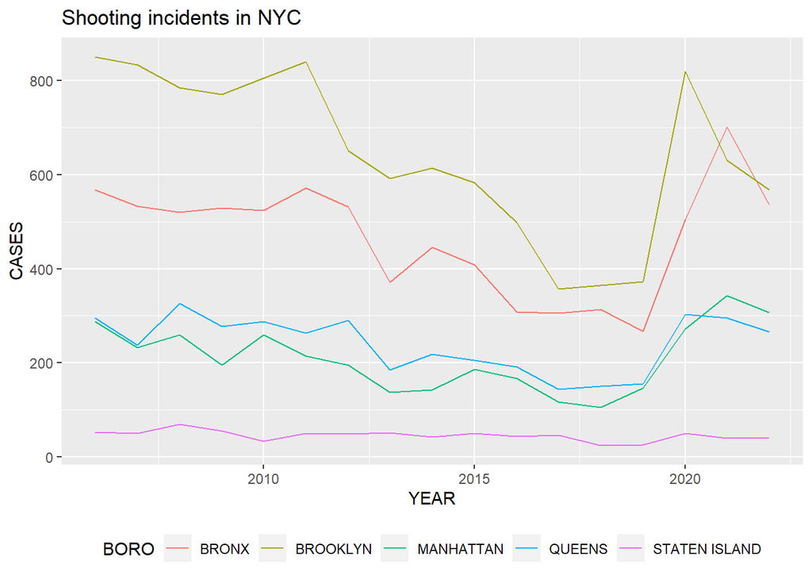

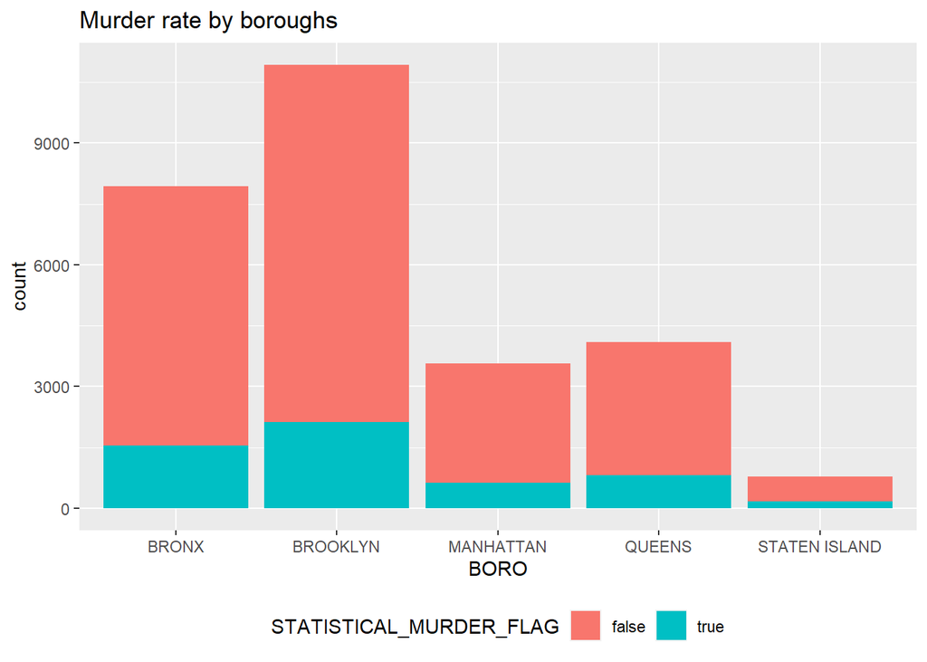

Then, I’ll visualize the demographics of perpetrators and victims respectively.

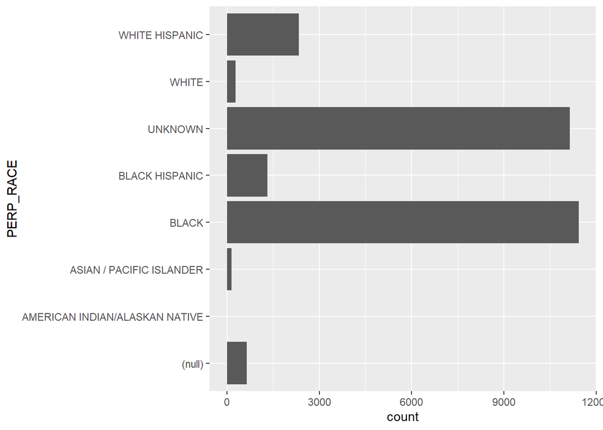

```r
ggplot(nypd) + geom_bar(aes(y = PERP_RACE))
```

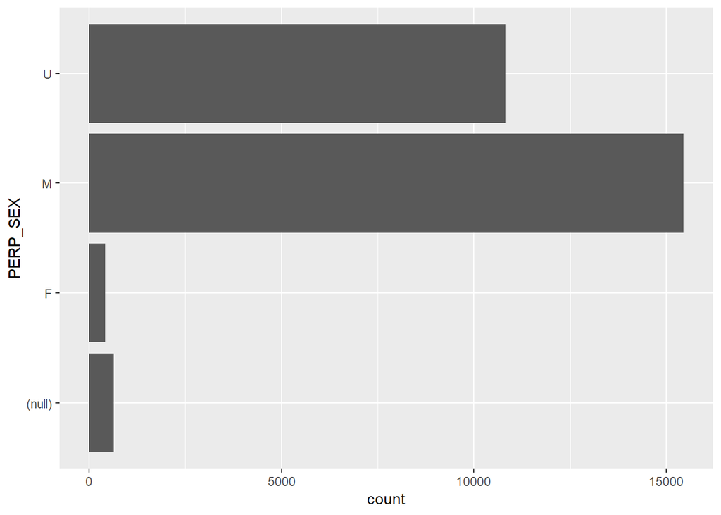

```r
ggplot(nypd) + geom_bar(aes(y = PERP_SEX))
```

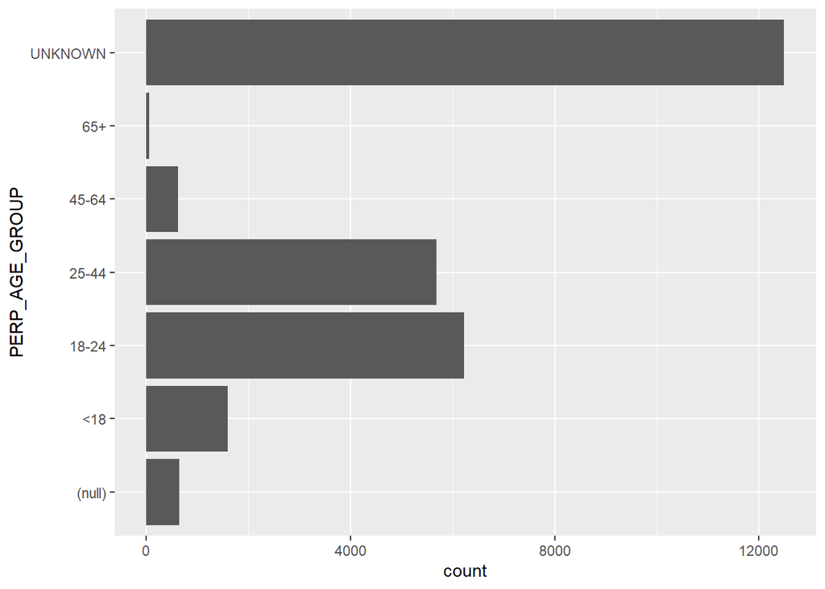

```r
ggplot(nypd) + geom_bar(aes(y = PERP_AGE_GROUP))
```

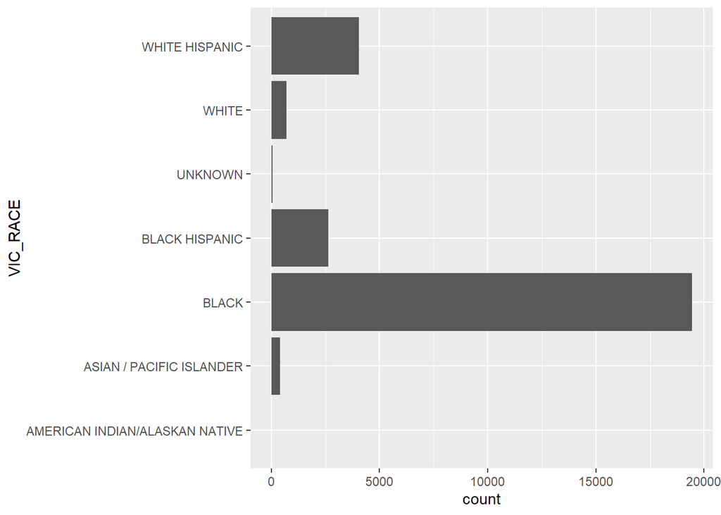

```r
ggplot(nypd) + geom_bar(aes(y = VIC_RACE))
```

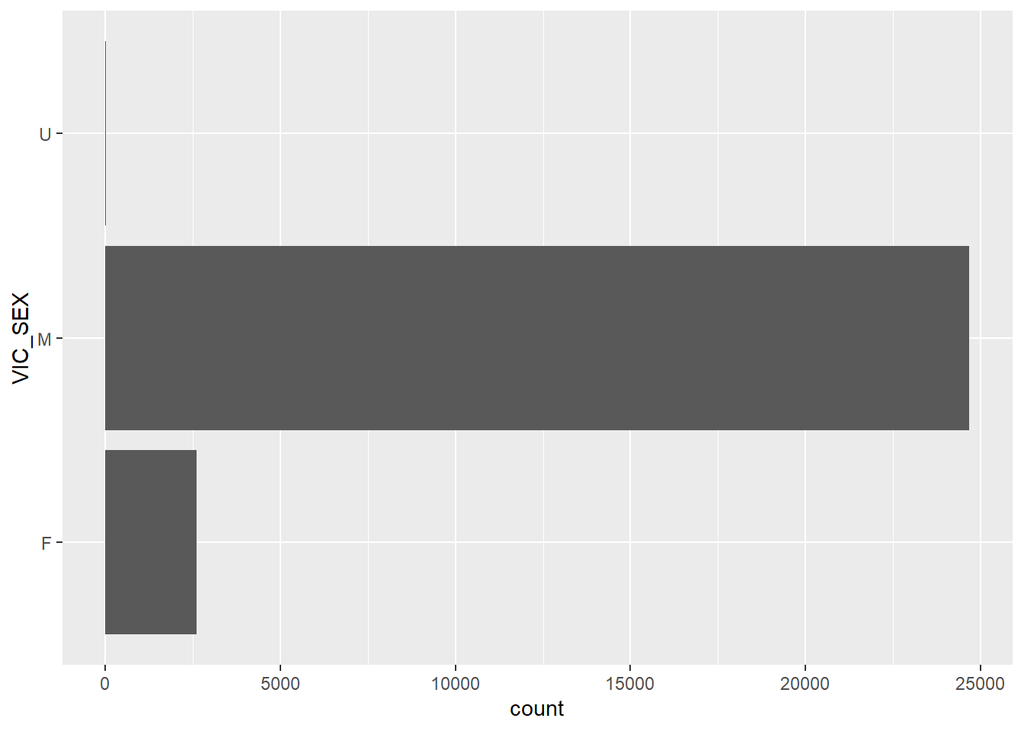

```r
ggplot(nypd) + geom_bar(aes(y = VIC_SEX))
```

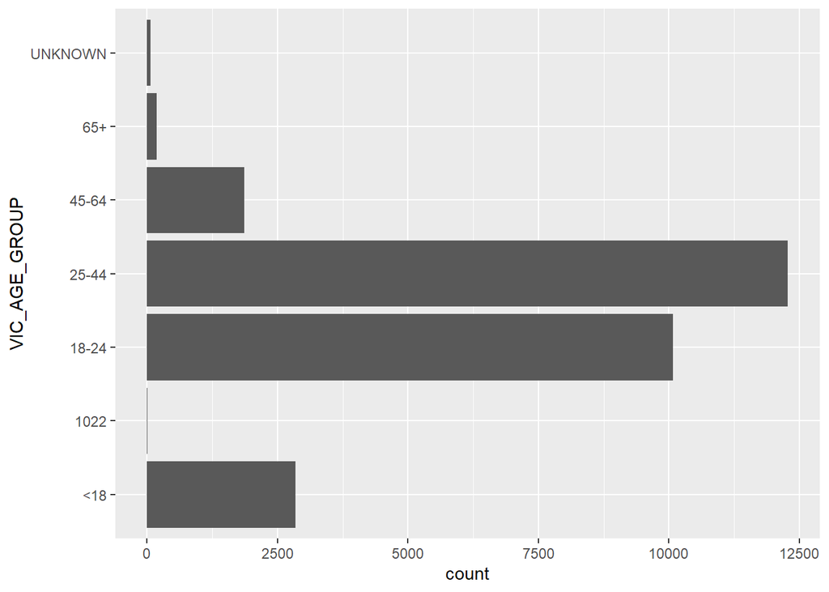

```r
ggplot(nypd) + geom_bar(aes(y = VIC_AGE_GROUP))
```

## Analysis

```r
murder_rate = table(nypd$BORO, nypd$STATISTICAL_MURDER_FLAG)
murder_rate
```

```
##
##                 false true
##   BRONX          6393 1542
##   BROOKLYN       8810 2122
##   MANHATTAN      2942  630
##   QUEENS         3284  810
##   STATEN ISLAND   614  162
```

Black males between age 18 and 44 are most likely the perpetrators of shooting crimes and equally likely to be the victims of such crimes at the same time. More resources should be allocated to educating and preventing this demographic group from committing gun violence.

## Model

```r
mod <- glm(STATISTICAL_MURDER_FLAG ~ PERP_RACE + PERP_SEX + PERP_AGE_GROUP + VIC_RACE + VIC_SEX + VIC_AGE_GROUP, family="binomial", data=nypd)
summary(mod)
```

```
##
## Call:
## glm(formula = STATISTICAL_MURDER_FLAG ~ PERP_RACE + PERP_SEX +
##     PERP_AGE_GROUP + VIC_RACE + VIC_SEX + VIC_AGE_GROUP, family = "binomial",
##     data = nypd)
##
## Coefficients: (2 not defined because of singularities)
##                                          Estimate Std. Error z value Pr(>|z|)
## (Intercept)                             -12.76988   96.67800  -0.132 0.894916
## PERP_RACEAMERICAN INDIAN/ALASKAN NATIVE -10.96308  229.62738  -0.048 0.961921
## PERP_RACEASIAN / PACIFIC ISLANDER         1.02004    0.29975   3.403 0.000667
## PERP_RACEBLACK                            0.64464    0.23858   2.702 0.006893
## PERP_RACEBLACK HISPANIC                   0.57471    0.24766   2.321 0.020312
## PERP_RACEUNKNOWN                          0.16439    0.11458   1.435 0.151383
## PERP_RACEWHITE                            1.16813    0.27396   4.264 2.01e-05
## PERP_RACEWHITE HISPANIC                   0.78040    0.24288   3.213 0.001313
## PERP_SEXF                                -2.49573    0.26608  -9.379  < 2e-16
## PERP_SEXM                                -2.61627    0.24043 -10.882  < 2e-16
## PERP_SEXU                                      NA         NA      NA       NA
## PERP_AGE_GROUP<18                         2.32785    0.17099  13.614  < 2e-16
## PERP_AGE_GROUP18-24                       2.42971    0.16067  15.122  < 2e-16
## PERP_AGE_GROUP25-44                       2.65706    0.16076  16.528  < 2e-16
## PERP_AGE_GROUP45-64                       2.94771    0.18040  16.340  < 2e-16
## PERP_AGE_GROUP65+                         3.01907    0.31388   9.619  < 2e-16
## PERP_AGE_GROUPUNKNOWN                          NA         NA      NA       NA
## VIC_RACEASIAN / PACIFIC ISLANDER         10.72968   96.67801   0.111 0.911629
## VIC_RACEBLACK                            10.56315   96.67793   0.109 0.912995
## VIC_RACEBLACK HISPANIC                   10.34138   96.67794   0.107 0.914815
## VIC_RACEUNKNOWN                           9.68125   96.67885   0.100 0.920235
## VIC_RACEWHITE                            10.62565   96.67798   0.110 0.912483
## VIC_RACEWHITE HISPANIC                   10.61594   96.67794   0.110 0.912562
## VIC_SEXM                                  0.03488    0.05312   0.657 0.511459
## VIC_SEXU                                 -0.45314    1.08287  -0.418 0.675607
## VIC_AGE_GROUP1022                       -10.85230  324.74370  -0.033 0.973341
## VIC_AGE_GROUP18-24                        0.26952    0.06307   4.273 1.93e-05
## VIC_AGE_GROUP25-44                        0.53248    0.06195   8.595  < 2e-16
## VIC_AGE_GROUP45-64                        0.63048    0.08036   7.846 4.30e-15
## VIC_AGE_GROUP65+                          0.89960    0.17704   5.081 3.75e-07
## VIC_AGE_GROUPUNKNOWN                      0.62695    0.31999   1.959 0.050078
##
```

[output cut: 26 more lines]

```
## VIC_AGE_GROUP18-24                      ***
## VIC_AGE_GROUP25-44                      ***
## VIC_AGE_GROUP45-64                      ***
## VIC_AGE_GROUP65+                        ***
## VIC_AGE_GROUPUNKNOWN                    .
## ---
## Signif. codes:  0 '***' 0.001 '**' 0.01 '*' 0.05 '.' 0.1 ' ' 1
##
## (Dispersion parameter for binomial family taken to be 1)
##
##     Null deviance: 26779  on 27308  degrees of freedom
## Residual deviance: 25689  on 27280  degrees of freedom
## AIC: 25747
##
## Number of Fisher Scoring iterations: 11
```

## Identify bias

One potential source of bias in this analysis is the lack of information on population and geography of the boroughs. Brooklyn may seem to be the most dangerous neighborhood in NYC judging from the total number of shooting incidents, but we really don’t know for sure until we factor in the population and land area of these boroughs. We can also question the reporting mechanism of these crimes. Black males are traditionally a very vulnerable group in the criminal justice system. There are a lot of prominent evidences as to how black males have been more targeted and mistreated in the legislative and law enforcement process. We should bear these bias in mind when analyzing and interpreting the results of how the data truly reflect the shooting crime landscape of NYC.